# Inflation Insights: Analyzing India’s Consumer Price Index (2013–2020)

Aashita Shukla

2025-06-19

## Introduction

This report presents an analysis of India’s Consumer Price Index (CPI) from 2013 to 2020 using publicly available government data. The objective is to evaluate inflation trends across major expenditure categories and understand the volatility of consumer prices using statistical and visualization techniques.

## Project Stack

- Data Wrangling: `readr`, `dplyr`, `tidyr`
- Date Parsing: `lubridate`
- Plotting: `ggplot2`
- Output: PDF report with high-resolution PNG plots

## Data Loading and Cleaning

```r
cpi <- read_csv("../data/All_India_Index_july2019_20Aug2020.csv")

cpi <- cpi %>%
  mutate(
    Month = str_to_title(trimws(Month)),
    Month = case_when(
      Month %in% c("Janaury", "Janurary") ~ "January",
      Month %in% c("Febuary", "Febraury") ~ "February",
      Month %in% c("Mar", "Marhc", "Marcrh") ~ "March",
      Month %in% c("Apr", "Apirl") ~ "April",
      Month %in% c("Jun") ~ "June",
      Month %in% c("Jul") ~ "July",
      Month %in% c("Sept", "Septmber", "Setpember") ~ "September",
      Month %in% c("Ocotber") ~ "October",
      Month %in% c("Noveber") ~ "November",
      Month %in% c("Deceber") ~ "December",
      TRUE ~ Month
    ),
    date = my(paste(Month, Year))
  ) %>%
  filter(!is.na(date))
```

## Data Transformation

```r
cpi_long <- cpi %>%
  pivot_longer(cols = `Cereals and products`:`Personal care and effects`,
               names_to = "category", values_to = "index") %>%
  filter(!is.na(index), !is.na(date)) %>%
  group_by(date, category) %>%
  summarise(index = mean(index), .groups = "drop")
```

## CPI Trends Over Time

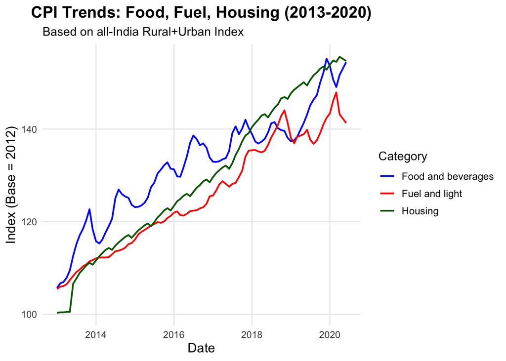

```r
key_categories <- c("Food and beverages", "Fuel and light", "Housing")

category_colors <- c(
  "Food and beverages" = "blue",
  "Fuel and light" = "red",
  "Housing" = "darkgreen"
)

ggplot(filter(cpi_long, category %in% key_categories),
       aes(x = date, y = index, color = category)) +
  geom_line(size = 0.8) +
  scale_color_manual(values = category_colors) +
  labs(title = "CPI Trends: Food, Fuel, Housing (2013-2020)",
       subtitle = "Based on all-India Rural+Urban Index",
       x = "Date", y = "Index (Base = 2012)", color = "Category") +
  theme_minimal(base_size = 12) +
  theme(
    plot.title = element_text(hjust = 0.5, face = "bold", size = 16),
    axis.title = element_text(size = 13),
    legend.title = element_text(size = 12),
    legend.text = element_text(size = 10),
    panel.grid.minor = element_blank()
  )
```

```r
ggsave("outputs/cpi_trend_plot.png", plot = last_plot(), width = 8, height = 4, dpi = 300)
```